# Data mobilisation from GBIF to the EBV Data Portal

Notebook 02 - Data exploration of species listed in the Birds Directive Annex I

Lina Estupinan-Suarez, Miguel Fernandez

German Centre for Integrative Biodiversity Research (iDiv)  
lina.estupinans@idiv.de

2024-08-16

### Introduction

In this notebook we explore the occurrence data of species listed in the Annex I of the Birds Directive available in GBIF until June 2024. To do this, a Birds occurrence cube was previously created using the [occurrence cube software](https://techdocs.gbif.org/en/data-use/data-cubes) developed by GBIF under the [Biodiversity Building Blocks for Policy (B3)](https://b-cubed.eu/) project. Details of the data query in GBIF are available at [doi: 10.15468/dl.uh84tp](https://doi.org/10.15468/dl.uh84tp/). The cube generation script is also part of this repository.

*Note: This series of notebooks is part of the results of Task 3.3 of the [Biodiversity Building Blocks for Policy](https://b-cubed.eu/) project funded by the European Union’s Horizon Europe Research and Innovation Programme (ID No 101059592). Additional notebooks exploring the results and calculating simple metrics are also available in the same repository.*

### Load library and input data

```r
rm(list=ls())
gc()
```

```
         used (Mb) gc trigger (Mb) max used (Mb)
Ncells 530560 28.4    1186898 63.4   657974 35.2
Vcells 969937  7.5    8388608 64.0  1768178 13.5
```

```r
# load requiered libraries
library(here)
library(b3gbi) # for csv occurrence cubes
library(ggplot2)
library(dplyr)
library(lubridate)
library(stringr)
```

After loading the necessary libraries, we load the occurrence cube of birds obtained previously through the GBIF API.

```r
# File name from the JSON query
occcube <- "0062979-240626123714530"

# Load occurrence cube using b3gbi
cin <- process_cube(here(paste0("output/datacubes/csv/birds/", occcube,".csv")))

# Load species taxonomy only with ‘accepted’ scientific names in the GBIF backbone taxonomy
tax <- read.csv(here("input/data/birds/taxonomy/list193birds_directive_annexi_allaccepted_usagekey_gbif.csv"))
```

### Data Analysis

#### Calculate Total Number of Occurrence

First we calculate the total number of occurence by family.

```r
cdata <- cin[["data"]]
# rename columns
colnames(cdata)[colnames(cdata) == "order"] <- "order_" # Note that if the name only remains as "order" this can be confused with the R funtcion 'order' to sort data.
colnames(cdata)[colnames(cdata) == "taxonKey"] <- "acceptedUsageKey"

# Aggregate occurrences at the family level
cag <- cdata %>%
  group_by(family) %>%
  summarize(totalOcc = sum(obs), Order = first(order_))

# Sort in ascending order
cag <- cag[order(cag$totalOcc), ]

# Save file
write.csv(cag, here("output/summary_data/csv/birds/summary_birds_total_occurrences_byfamily+order.csv"))
```

Now, we calculate the total number of occurence by species.

```r
# Aggregate occurrences at species level
cag_sp <- cdata %>%
  group_by(acceptedUsageKey) %>%
  summarize(totalOcc = sum(obs))

# Sort in ascending order
cag_sp <- cag_sp[order(cag_sp$totalOcc), ]

# Check family with one record
position <- which(cdata$family == "Columbidae")
second_row <- cdata %>%
  slice(position)
as.data.frame(second_row) # taxon key 2495406
```

| yearMonth | cellCode | basisofrecord | datasetkey | countrycode | acceptedUsageKey | scientificName | family | class | order_ | obs | year | xcoord | ycoord | resolution |
| --- | --- | --- | --- | --- | --- | --- | --- | --- | --- | --- | --- | --- | --- | --- |
| 2010-12 | 10kmE271N196 | HUMAN_OBSERVATION | 8ea87d00-f94e-4221-8f2f-2e9150132361 | PT | 2495406 | Columba trocaz | Columbidae | Aves | Columbiformes | 1 | 2010 | 271 | 196 | 10km |

```r
# Rename columns for joining occurence cube with GBIF Backbone taxonomy. Remember our species identifier is the 'acceptedUsageKey'

# Merge data sets and sort in ascending order
xout <- cag_sp %>%
  inner_join(tax[,c("scientificName", "key", "kingdom", "phylum", "class", "order", "family", "acceptedUsageKey")], by = "acceptedUsageKey")

xout <- xout[order(xout$totalOcc), ]

# Save file
write.csv(xout, here("output/summary_data/csv/birds/summary_birds_total_occurrences_acceptedusagekey.csv"))
```

#### Identify birds without species occurrences through the GBIF occurrence cube software

```r
# Find what species have no records in GBIF
noocc <- anti_join(tax, cag_sp, by = "acceptedUsageKey")
write.csv(noocc, here("output/summary_data/csv/birds/birds_no_occurrences_acceptedusagekeys.csv"))
print(noocc[,c("scientificName", "acceptedUsageKey")])
```

```
                                             scientificName acceptedUsageKey
1       Accipiter gentilis arrigonii (O.Kleinschmidt, 1903)          4408405
2                       Accipiter nisus granti Sharpe, 1890          4408410
3      Anser albifrons flavirostris Dalgety & P.Scott, 1948          6178325
4    Calidris alpina schinzii (C.L.Brehm & Schilling, 1822)          6177960
5             Certhia brachydactyla dorotheae Hartert, 1904          4408795
6                               Columba bollii Godman, 1872          2495427
7                            Columba junoniae Hartert, 1916          2495434
8                    Columba palumbus azorica Hartert, 1905          2495459
9          Dendrocopos major canariensis (A.F.Koenig, 1889)          6177296
10                  Dendrocopos major thanneri le Roi, 1911          6177279
11                                        Egretta alba alba          7190969
12                 Fringilla coelebs ombriosa Hartert, 1913          6175538
13   Fringilla teydea Webb, Berthelot & Moquin-Tandon, 1836          2494442
14                           Gelochelidon nilotica nilotica          7192423
15                                 Lagopus mutus helveticus          5227692
16                   Lagopus mutus pyrenaicus Hartert, 1921          5227710
17                       Parus ater cypriotes Dresser, 1888          5844831
18               Perdix perdix hispaniensis Reichenow, 1892          2473966
19                    Perdix perdix italica E.Hartert, 1917          2473961
20 Phalacrocorax aristotelis desmarestii (Payraudeau, 1826)          4408479
21                             Pyrrhula murina Godman, 1866          4408970
22                    Saxicola dacotiae (Meade-Waldo, 1889)          2492522
23                                     Tetrao tetrix tetrix          7191070
24    Troglodytes troglodytes fridariensis Williamson, 1951          5739334
25                         Uria aalge ibericus Bernis, 1948          6065721
```

As a remark, the list above refers mostly to subspecies that cannot be identified by the ‘speciesKey’ of our JSON query, and a few correspond to species from the Canary Islands or the Azores that are not covered by the EEA grid.

#### Prepare taxonomy for the EBV Data Portal

Due to the absence of data for 25 species, we prepared a new file including only taxonomic information of 168 species based on our results.

```r
# Filter taxonomy file for only species with data
# Import file for all Birds Species and following the ebvcube format

# Subset only for species with data occurrences in GBIF
spskey <- unique(cin[["data"]][["taxonKey"]]) # "taxonKey" is the name of the species key in b3bgi

gbif_spx <- tax %>%
  filter(acceptedUsageKey %in% spskey)

# Unmatched species
gbif_spx_missing <- tax %>%
  filter(acceptedUsageKey %in% setdiff(tax$acceptedUsageKey, spskey))

# Sort the right taxonomic order for filling the EBV Data Portal requierement before saving
gbif_spx2 <- gbif_spx[,c("kingdom", "phylum", "class", "order", "family", "genus", "species", "acceptedUsageKey", "scientificName")]

# Save files
write.csv(gbif_spx2[,1:8], here("input/data/birds/taxonomy/list168_BirdsAnnexI_gbif_accepted_ebvcube+acceptedUsageKey.csv"), quote=FALSE)
write.csv(gbif_spx2, here("input/data/birds/taxonomy/list168_BirdsAnnexI_gbif_accepted_ebvcube+acceptedUsageKey+ETCname.csv"))
write.csv(gbif_spx_missing, here("input/data/birds/taxonomy/list_missing_BirdsAnnexI_gbif_accepted_ebvcube+acceptedUsageKey.csv"), quote=FALSE)
```

### Data Exploration

We will start checking the number of records since 1950.

```r
# Convert date from character to numeric
todates <- as.data.frame(str_split(cdata$yearMonth, "-", simplify = TRUE))
colnames(todates) <- c("year", "month")

# Add year and month columns separate to the initial dataset
cdata$year <- todates$year
cdata$month <- todates$month

# Filter data starting from 1950
cdata2 <- cdata %>%
  filter(year > 1950)

# Group data by year
cag_year <- cdata2 %>%
    group_by(year) %>%
  summarize(totalOcc = sum(obs))

# Group data by month
cag_month <- cdata %>%
    group_by(month) %>%
  summarize(totalOcc = sum(obs))
```

In the following code chunk we plot the GBIF occurrences available since 1950 for the Bird Directive species in Annex I.

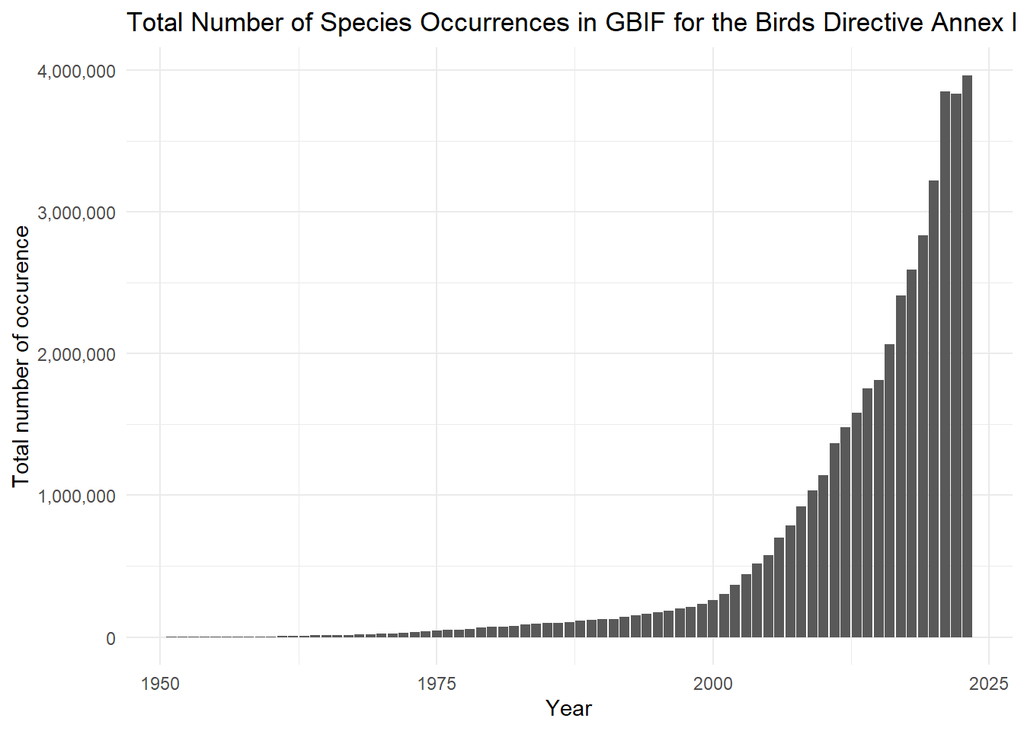

```r
ggplot(cag_year, aes(x = as.numeric(year), y = totalOcc)) +
  geom_bar(stat = "identity") +
  # guides(fill=guide_legend(ncol=1)) +
  scale_y_continuous(label = scales::label_comma(accuracy = 1)) +
  # coord_flip() +
  labs(title = "Total Number of Species Occurrences in GBIF for the Birds Directive Annex I since 1950",
       x = "Year",
       y = "Total number of occurence") +
       guides(color = guide_legend(override.aes = list(size = 5))) +
  theme_minimal()
```

Now we plot the all GBIF occurrences per month for the Bird Directive species in Annex I.

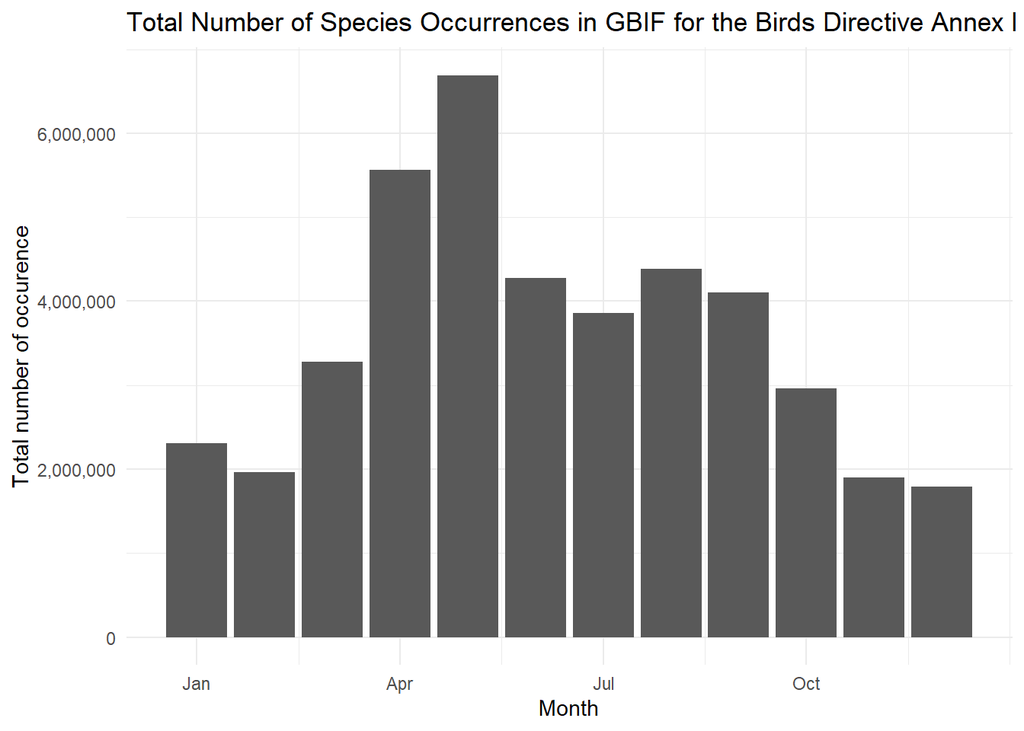

```r
ggplot(cag_month, aes(x = as.numeric(month), y = totalOcc)) +
  geom_bar(stat = "identity") +
  # guides(fill=guide_legend(ncol=1)) +
  scale_x_continuous(breaks = c(1,4,7,10), labels = c("Jan", "Apr", "Jul", "Oct")) +
  scale_y_continuous(label = scales::label_comma(accuracy = 1)) +
  labs(title = "Total Number of Species Occurrences in GBIF for the Birds Directive Annex I per month",
       x = "Month",
       y = "Total number of occurence") +
       guides(color = guide_legend(override.aes = list(size = 5))) +
  theme_minimal()
```

The next plot shows the occurrence of birds by family and the bars are coloured by the taxonomic order.

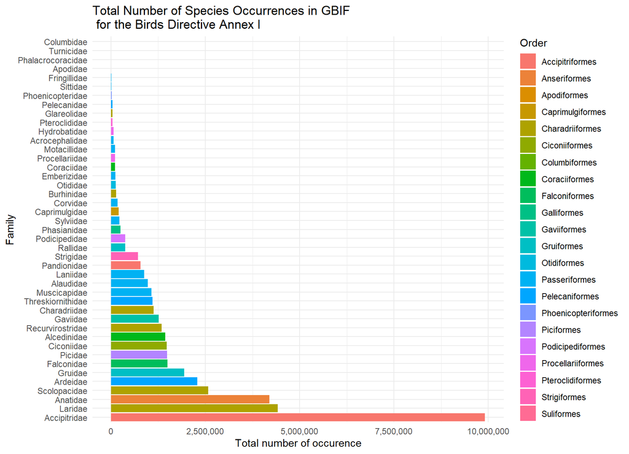

```r
# Create a horizontal bar plot
ggplot(cag, aes(x = reorder(family, -totalOcc), y = totalOcc, fill = Order)) +
  geom_bar(stat = "identity") +
  guides(fill=guide_legend(ncol=1)) +
  scale_y_continuous(label = scales::label_comma(accuracy = 1)) +
  coord_flip() +
  labs(title = "Total Number of Species Occurrences in GBIF\n for the Birds Directive Annex I",
       x = "Family",
       y = "Total number of occurence") +
       guides(color = guide_legend(override.aes = list(size = 5))) +
  theme_minimal()
```

```r
# Select the five species with more records
cag_sel <- cag_sp[(dim(cag_sp)[1]-5):dim(cag_sp)[1],]

# Subset data set
cag_top5 <- cdata %>%
  inner_join(cag_sel[,c("acceptedUsageKey")], by = "acceptedUsageKey") %>%
  filter(year > 1990)

# Aggregate occurrences by year
cag_top5year <- cag_top5 %>%
  group_by(year, scientificName) %>%
  summarize(totalOcc = sum(obs), scientificName = first(scientificName))
```

[figure not shown]

```r
ggplot(cag_top5year, aes(x = as.numeric(year), y = totalOcc, color = scientificName, name = "Species")) +
  geom_line(linewidth = 1.3) +
  guides(color=guide_legend(ncol=1, title = "Species")) +
  labs(title = "Annual species occurrences since 1990 for the top five \n GBIF occurrence of species listed in Annex I of the Birds Directive",
       x = "Time",
       y = "Total number of occurence") +
  theme_minimal()
```